# Summer Academy NPS Data Assignment slides

DS 1: Data Analysis, Visualization & Databases Project 1 Guidelines: Summer Academy NPS Data

Project Timeline Description & data given: Tuesday, January 30th Data cleaning check-in: Thursday, February 1st In-class presentations: Tuesday, February 6th

Project Summary For your first major project of DS 1, you’ll be investigating real-world data from feedback surveys completed during Make School’s very own Summer Academy program! Completing this project will you’ll strengthen your understanding of: The overall Data Science process (define, measure, analyze, improve, control) Aggregating data sets from multiple files, locations, and types The importance of scripting and automating data preprocessing Transforming data so that it has the same scale and data type Best practices for investigating data and asking interesting questions Data Visualization strategies Distilling findings down into small, understandable, non-technical (!) presentations

Description of Problem Clean and investigate Make School NPS data to find interesting and actionable trends that help inform decision-makers. Create a presentation in a Jupyter Notebook using data visualizations and other techniques that allow non-technical team members to understand your findings.

Background on NPS Every summer, Make School welcomes hundreds of students into the Summer Academy to study software development and build cool stuff. The management wants to make sure that students continue to be satisfied with their experience as the program scales. The main way we measure this is through Net Promoter Score (NPS), which is a tool commonly used to measure customer loyalty and promotion. You’ve seen NPS before if you’ve been asked a question like: “On a scale of 1 to 10, how likely are you to recommend [X] to a friend or colleague?”

NPS segments all responses between 1 and 10 into three categories based on their sentiment: Promoter (9 – 10) Passive (7 – 8) Detractor (1 – 6)

To calculate NPS, companies follow these steps: Segment all responses into Promoter, Passive, and Detractor categories. Calculate the percentage of responses in each category out of the total number of responses to the survey. Subtract the Detractors percentage from the Promoters percentage. This is the NPS.

In other words, NPS can be calculated with this equation: NPS = (Promoters - Detractors) (Promoters + Passives + Detractors)

NPS can range from –100 (if everyone is a detractor) to +100 (if everyone is a promoter).

For more detailed information on NPS, read this article.

Background on Data Set Make School’s Summer Academy typically last for 8 weeks, although this can vary by location. Every week, students are given a survey asking their satisfaction with the program in the form of an NPS question (see example question in “Background on NPS” section).

You have been given data from Summer Academy in 2016 and 2017. Download the data here. We will do an initial data investigation during class to get a feel for how the data is structured.

You should create a data dictionary that describes what each column’s possible values mean.

Questions to Consider Answering In this scenario, you’ve just been given access to this data from your boss, with the instructions to “See if you can find anything in here that can help the business.” – This is a very broad set of instructions. In order to complete this task well, you may want to consider finding answers to the following questions: What are things we could find here that could “help the business”? What sorts of information does this data set contain? What kinds of questions might we be able to answer with this data? What kinds of questions can’t we answer with this data? What sorts of information might be actionable? How can you present your findings in a way that non-technical employees can understand and use to make decisions?

Data Wrangling Issues to Consider CSV files may have header rows Collating data from multiple sources Introducing new columns/attributes Converting data types (string values to integers) Converting categorical values (either to integers or one-hot encoding) Normalizing values based on different units

```python
# Run this cell to import the packages you'll need
import numpy as np
import pandas as pd
import matplotlib.pyplot as plt
import glob
import csv
%matplotlib inline
```

```python
# Define the locations of the datasets
nps2017_location = "datasets/SA Feedback Surveys/2017"
nps2017_scores_file = nps2017_location + "/Student Feedback Surveys-Superview.csv"
nps2016_location = "datasets/SA Feedback Surveys/2016/Standard Surveys"

# Define location where cleaned data should be saved
cleaned_file = "datasets/SA Feedback Surveys/2016/cleaned_2016.csv"

# Define location of file we will use to output the merged data of 2016 and 2017
merge_file = "datasets/SA Feedback Surveys/merged_surveys.csv"

# Define the meanings of the city abbreviations in 2016 Dataset for converting to match 2017 dataset
city_abbr_key = {"LA": "Los Angeles", "SF": "San Francisco", "NY": "New York City", "SG": "Singapore", "Singapore": "Singapore", "SV": "Sunnyvale", "HK": "Hong Kong"}

# Define the meanings of the "Schedule Pacing" as integers for better analysis
pacing_conversion_key = {"Way too slow": "1", "A little too slow": "2", "Just right": "3", "A little too fast": "4", "Way too fast": "5"}

# Key for converting "track" from 2016 week 8 data to "track" in 2017 dataset
track_conversion_key = {"summerApps": "Apps", "summerIntro": "\"Apps, Explorer\"", "summerGames": "Games", "summerVR": "VR"}

# Net Promoter Score calculation
def nps_calc(promoters, detractors, total):
    return (promoters - detractors) / total
```

```python
# Process the 2016 standard files into the "cleaned_2016.csv" file
def read_and_clean_to_file(read_filenames, write_filename):

    write_csv = csv.writer(open(write_filename, 'w', newline=''))
    rows_to_write = []

    for filename in read_filenames:
        csv_line = ","
        a, b = filename.find('- '), filename.find('.')
        city = filename[a+2:b]
        if len(city) == 2:
            city = city_abbr_key[city]

        a, b = filename.find('Week '), filename.find(' Feedback -')
        week = filename[a+5:b]


        # Read the file, through each line
        file_reader = csv.reader(open(filename, newline=''), delimiter=",")

        header = next(file_reader) #header

        for row in file_reader:
            row_key = {}
            track = ""
            pacing = ""

            # Generate indices of the different values we are looking for
            for key in header:
                row_key[key] = header.index(key)


            satisfaction = row[row_key["How would you rate your overall satisfaction with the Summer Academy this week?"]]

            # Not all files have the track
            if ("What track are you in?" in row_key.keys()):
                track = row[row_key["What track are you in?"]]

            # Some ask for "schedule" pacing, others for "tutorial" pacing
            if ("How well is the schedule paced?" in row_key.keys()):
                pacing = row[row_key["How well is the schedule paced?"]]
            if ("How well are the tutorials paced?" in row_key.keys()):
                pacing = row[row_key["How well are the tutorials paced?"]]

            # Construct the line for writing to the csv file.
            csv_line = ['', city, track, week, str(int(satisfaction) * 2), pacing, 2016]
            rows_to_write.append(csv_line)

    write_csv.writerows(rows_to_write)
```

```python
# Iterate through the files in 2016 to pull out the Week, City, Satisfaction Rating, and Pace Rating
# Format for data: ID, Location, Track, Week, Rating (Num), Pacing

filenames = []

for filename in glob.iglob(nps2016_location + '/*.csv'):
    filenames.append(filename)

read_and_clean_to_file(filenames, cleaned_file)
```

```python
# Now that we've cleaned the 2016 data, we can combine the 2016 and the 2017 data
fout=open(merge_file,"a")
# 2017 data:
for line in open(nps2017_scores_file):
    match = next((x for x in pacing_conversion_key.keys() if x in line), False)
#     print(match)
    if(match):
        line = line.replace(match, pacing_conversion_key[match])
    if ("Location" in line):
        index = line.find("\n")
        line = line[:index] + ",Year" + line[index:]
    else:
        if ("\n" not in line):
            line += "\n"
        index = line.find("\n")
        line = line[:index] + ",2017" + line[index:]
    if ("Week " in line):
        index = line.find("Week ")
        line = line[:index] + line[index+5:]
    fout.write(line)
# 2016 data (cleaned):
for line in open(cleaned_file):
    fout.write(line)

fout.close()
```

```python
# Well, now that the data is cleaned and merged, we can do all sorts of fun stuff with it!
makeschool_surveys_df = pd.read_csv(merge_file)

makeschool_surveys_df.describe()
```

|  | ID | Week | Rating (Num) | Schedule Pacing | Year |
| --- | --- | --- | --- | --- | --- |
| count | 1450.000000 | 2376.000000 | 2376.000000 | 2376.000000 | 2376.000000 |
| mean | 757.922069 | 3.510522 | 8.401515 | 3.205808 | 2016.610269 |
| std | 430.382155 | 2.005858 | 1.507169 | 0.615026 | 0.487792 |
| min | 8.000000 | 1.000000 | 0.000000 | 1.000000 | 2016.000000 |
| 25% | 386.250000 | 2.000000 | 8.000000 | 3.000000 | 2016.000000 |
| 50% | 762.500000 | 3.000000 | 8.000000 | 3.000000 | 2017.000000 |
| 75% | 1129.750000 | 5.000000 | 10.000000 | 4.000000 | 2017.000000 |
| max | 1499.000000 | 8.000000 | 10.000000 | 5.000000 | 2017.000000 |

```
array([[<matplotlib.axes._subplots.AxesSubplot object at 0x10259a320>]], dtype=object)
```

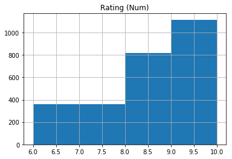

```python
makeschool_surveys_df
makeschool_surveys_df.hist("Rating (Num)", bins=[6, 8, 9, 10], range=[0.0,10.0])
```

```python
ms_promoters = len(makeschool_surveys_df[makeschool_surveys_df["Rating (Num)"] >= 9])
ms_detractors = len(makeschool_surveys_df[makeschool_surveys_df["Rating (Num)"] <= 6])
ms_total = len(makeschool_surveys_df)

print(nps_calc(ms_promoters, ms_detractors, ms_total))
```

```
0.35648148148148145
```

```python
# Let's compare, for example, total NPS scores across all weeks in 2016 with NPS scores across all weeks in 2017
nps_by_week_2016 = []
nps_by_week_2017 = []

# Gather all of the weekly scores for 2016
for i in range(1, 8):
    weekly_nps_df = makeschool_surveys_df[(makeschool_surveys_df["Week"] == i) & (makeschool_surveys_df["Year"] == 2016)]
    weekly_prom = len(weekly_nps_df[weekly_nps_df["Rating (Num)"] >= 9])
    weekly_dect = len(weekly_nps_df[weekly_nps_df["Rating (Num)"] <= 6])
    weekly_total = len(weekly_nps_df)
    weekly_nps_score = nps_calc(weekly_prom, weekly_dect, weekly_total)
    nps_by_week_2016.append(weekly_nps_score)

# Gather all of the weekly scores for 2017
for i in range(1, 9):
    weekly_nps_df = makeschool_surveys_df[(makeschool_surveys_df["Week"] == i) & (makeschool_surveys_df["Year"] == 2017)]
    weekly_prom = len(weekly_nps_df[weekly_nps_df["Rating (Num)"] >= 9])
    weekly_dect = len(weekly_nps_df[weekly_nps_df["Rating (Num)"] <= 6])
    weekly_total = len(weekly_nps_df)
    weekly_nps_score = nps_calc(weekly_prom, weekly_dect, weekly_total)
    nps_by_week_2017.append(weekly_nps_score)
```

Now that we've gathered all of the NPS Scores by week for 2016 and 2017, we can easily compare them to see how they changed!

NPS is usually plotted on a scale of -100 - 100, so let's see what that looks like!

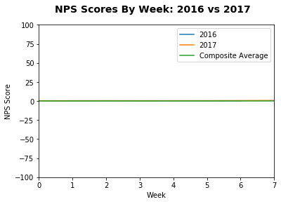

```python
fig = plt.figure()
fig.suptitle('NPS Scores By Week: 2016 vs 2017', fontsize=14, fontweight='bold')

plt.plot(nps_by_week_2016)
plt.plot(nps_by_week_2017)
plt.plot([0.35648148148148145, 0.35648148148148145, 0.35648148148148145, 0.35648148148148145, 0.35648148148148145, 0.35648148148148145, 0.35648148148148145, 0.35648148148148145])
plt.axis([0,7,-100,100])
plt.legend(['2016', '2017', 'Composite Average'])
plt.xlabel("Week")
plt.ylabel("NPS Score")
plt.show()
```

Well that's not terribly helpful. Nothing seems to have changed! Let's zoom in a bit and see how accurate that is.

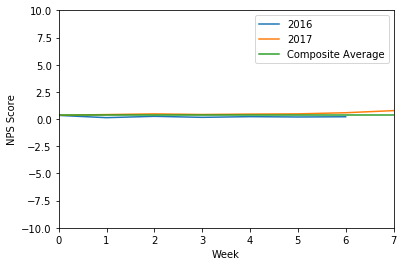

```python
plt.plot(nps_by_week_2016)
plt.plot(nps_by_week_2017)
plt.plot([0.35648148148148145, 0.35648148148148145, 0.35648148148148145, 0.35648148148148145, 0.35648148148148145, 0.35648148148148145, 0.35648148148148145, 0.35648148148148145])
plt.axis([0,7,-10,10])
plt.legend(['2016', '2017', 'Composite Average'])
plt.xlabel("Week")
plt.ylabel("NPS Score")
plt.show()
```

Well that looks a bit different. 2017 seems like there was some definite improvement, especially as the weeks go on.

Let's zoom in just a bit further and see how they stack up.

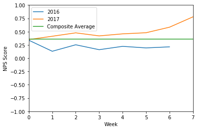

```python
plt.plot(nps_by_week_2016)
plt.plot(nps_by_week_2017)
plt.plot([0.35648148148148145, 0.35648148148148145, 0.35648148148148145, 0.35648148148148145, 0.35648148148148145, 0.35648148148148145, 0.35648148148148145, 0.35648148148148145])
plt.axis([0,7,-1,1])
plt.legend(['2016', '2017', 'Composite Average'])
plt.xlabel("Week")
plt.ylabel("NPS Score")
plt.show()
```

Wow! At this scale it looks like 2017 was WAY better than 2016. But check out the y-axis.

However, when we think about this in terms of percentages, the overall improvement can be viewed as well.

First, let's see what the average was for each year:

```python
avg_nps_2016 = sum(nps_by_week_2016) / len(nps_by_week_2016)

avg_nps_2017 = sum(nps_by_week_2017) / len(nps_by_week_2017)

print(avg_nps_2016)
print(avg_nps_2017)

print(avg_nps_2017 / avg_nps_2016)
```

```
0.21590172482193637
0.4948729751937261
2.2921214529521223
```

Based on this, our average NPS Score for 2017 was 2.3x higher than in 2016! Incredible!

One anomaly in the data you may have noticed is that there is no NPS score for week 8 in 2016. Why is this?

Well, the question for Weeks 1-7 in 2016 was "How would you rate your overall satisfaction with the Summer Academy this week?" while the question in Week 8 was changed to "How likely is it that you would recommend the Make School Summer Academy to a friend?" Since these two questions are markedly different, we have opted not to include it in our analysis.

Additionally, the Week 8 survey responses are labeled as "Incomplete", which further brings the value of those results into question.

What other things can this data tell us?

Well, if the NPS Scores improved, what might be the reason?

Let's see if there is a correlation between NPS Score on Satisfaction with the Summer Academy and NPS Score on Pacing at the Summer Academy:

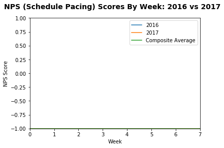

```python
# First, let's gather all of the data we need from 2016 and 2017. Specifically, let's get the "Pacing" scores:
pacing_nps_by_week_2016 = []
pacing_nps_by_week_2017 = []

# Gather all of the weekly scores for 2016
for i in range(1, 8):
    weekly_nps_df = makeschool_surveys_df[(makeschool_surveys_df["Week"] == i) & (makeschool_surveys_df["Year"] == 2016)]
    weekly_prom = len(weekly_nps_df[weekly_nps_df["Schedule Pacing"] >= 9])
    weekly_dect = len(weekly_nps_df[weekly_nps_df["Schedule Pacing"] <= 6])
    weekly_total = len(weekly_nps_df)
    weekly_nps_score = nps_calc(weekly_prom, weekly_dect, weekly_total)
    pacing_nps_by_week_2016.append(weekly_nps_score)

# Gather all of the weekly scores for 2017
for i in range(1, 9):
    weekly_nps_df = makeschool_surveys_df[(makeschool_surveys_df["Week"] == i) & (makeschool_surveys_df["Year"] == 2017)]
    weekly_prom = len(weekly_nps_df[weekly_nps_df["Schedule Pacing"] >= 9])
    weekly_dect = len(weekly_nps_df[weekly_nps_df["Schedule Pacing"] <= 6])
    weekly_total = len(weekly_nps_df)
    weekly_nps_score = nps_calc(weekly_prom, weekly_dect, weekly_total)
    pacing_nps_by_week_2017.append(weekly_nps_score)

# Then, let's graph that information as well. We already know that the scores are usually pretty close, so let's
# skip ahead a bit and zoom in.
fig = plt.figure()
fig.suptitle('NPS (Schedule Pacing) Scores By Week: 2016 vs 2017', fontsize=14, fontweight='bold')

# Let's calculate the total composite NPS, too, that way we can compare each week of each year to the average of all
ms_pacing_promoters = len(makeschool_surveys_df[makeschool_surveys_df["Schedule Pacing"] >= 9])
ms_pacing_detractors = len(makeschool_surveys_df[makeschool_surveys_df["Schedule Pacing"] <= 6])

avg_pacing_nps = nps_calc(ms_pacing_promoters, ms_pacing_detractors, ms_total)
avg_pacing_series = []

for i in range(1, 9):
    avg_pacing_series.append(avg_pacing_nps)

plt.plot(pacing_nps_by_week_2016)
plt.plot(pacing_nps_by_week_2017)
plt.plot(avg_pacing_series)
plt.axis([0,7,-1,1])
plt.legend(['2016', '2017', 'Composite Average'])
plt.xlabel("Week")
plt.ylabel("NPS Score")
plt.show()
```

Uh oh! It looks like we don't have any data! What happened?

Well, it looks like our values might be below our bottom value on the y-axis, so let's try adjusting our scale a bit:

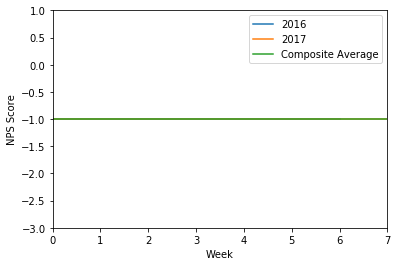

```python
plt.plot(pacing_nps_by_week_2016)
plt.plot(pacing_nps_by_week_2017)
plt.plot(avg_pacing_series)
plt.axis([0,7,-3,1])
plt.legend(['2016', '2017', 'Composite Average'])
plt.xlabel("Week")
plt.ylabel("NPS Score")
plt.show()
```

Hmmm...Something seems off with our data. What could it be?

Well, it's more likely that something is wrong with the way we processed the data, so let's take a look there to see:

```
weekly_nps_df = makeschool_surveys_df[(makeschool_surveys_df["Week"] == i) & (makeschool_surveys_df["Year"] == 2016)]
```

Can you see where the problem is?

Well, for "Schedule Pacing" the scale goes from 1-5, rather than from 1-10, with 1 being "way too slow" and 5 being "way too fast". So, for this particular grouping of data, it doesn't make sense to process it the same as normal NPS.

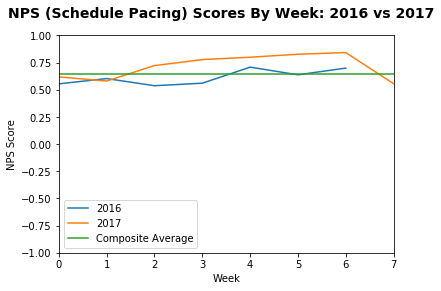

```python
# We have to reprocess the data, because our old data was processed incorrectly.
pacing_nps_by_week_2016 = []
pacing_nps_by_week_2017 = []

# Gather all of the weekly scores for 2016
for i in range(1, 8):
    weekly_nps_df = makeschool_surveys_df[(makeschool_surveys_df["Week"] == i) & (makeschool_surveys_df["Year"] == 2016)]
    weekly_prom = len(weekly_nps_df[weekly_nps_df["Schedule Pacing"] == 3])
    weekly_dect = len(weekly_nps_df[(weekly_nps_df["Schedule Pacing"] == 1) | (weekly_nps_df["Schedule Pacing"] == 1)])
    weekly_total = len(weekly_nps_df)
    weekly_nps_score = nps_calc(weekly_prom, weekly_dect, weekly_total)
    pacing_nps_by_week_2016.append(weekly_nps_score)

# Gather all of the weekly scores for 2017
for i in range(1, 9):
    weekly_nps_df = makeschool_surveys_df[(makeschool_surveys_df["Week"] == i) & (makeschool_surveys_df["Year"] == 2017)]
    weekly_prom = len(weekly_nps_df[weekly_nps_df["Schedule Pacing"] == 3])
    weekly_dect = len(weekly_nps_df[(weekly_nps_df["Schedule Pacing"] == 1) | (weekly_nps_df["Schedule Pacing"] == 1)])
    weekly_total = len(weekly_nps_df)
    weekly_nps_score = nps_calc(weekly_prom, weekly_dect, weekly_total)
    pacing_nps_by_week_2017.append(weekly_nps_score)


# Let's calculate the total composite NPS, too, that way we can compare each week of each year to the average of all
ms_pacing_promoters = len(makeschool_surveys_df[makeschool_surveys_df["Schedule Pacing"] == 3])
ms_pacing_detractors = len(makeschool_surveys_df[(makeschool_surveys_df["Schedule Pacing"] == 1) | (makeschool_surveys_df["Schedule Pacing"] == 5)])

avg_pacing_nps = nps_calc(ms_pacing_promoters, ms_pacing_detractors, ms_total)
avg_pacing_series = []

for i in range(1, 9):
    avg_pacing_series.append(avg_pacing_nps)

# Let's try graphing that again.
fig = plt.figure()
fig.suptitle('NPS (Schedule Pacing) Scores By Week: 2016 vs 2017', fontsize=14, fontweight='bold')

plt.plot(pacing_nps_by_week_2016)
plt.plot(pacing_nps_by_week_2017)
plt.plot(avg_pacing_series)
plt.axis([0,7,-1,1])
plt.legend(['2016', '2017', 'Composite Average'])
plt.xlabel("Week")
plt.ylabel("NPS Score")
plt.show()
```

Wow, now the data is all over the place!

Before, all of our collected data pointed towards an NPS score of -1, or possibly even lower, but once we processed and analyzed the data correctly, we can clearly see that the overall pacing score is much higher (and positive, which is good!).

Now, let's take a look at both graphs side-by-side to see if there is a correlation between the two:

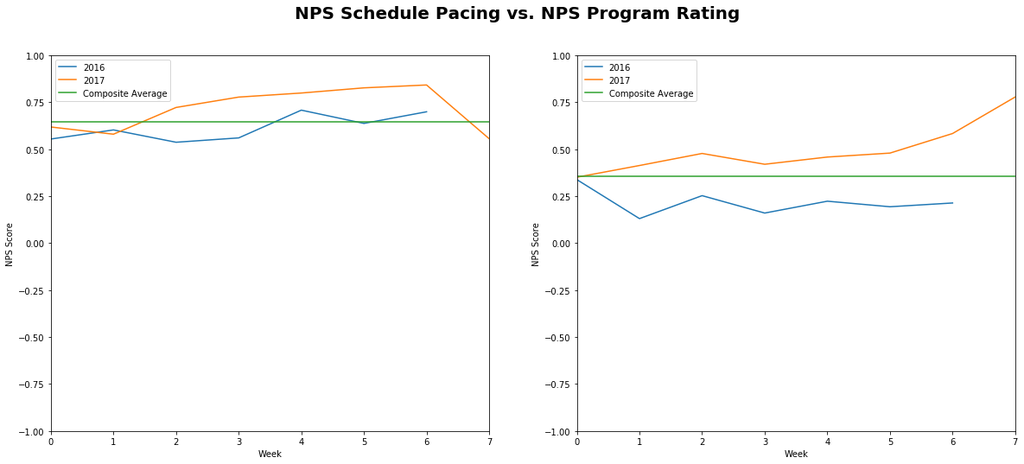

```python
# First, the Pacing NPS scores:
fig = plt.figure(figsize=(20, 8))
fig.suptitle('NPS Schedule Pacing vs. NPS Program Rating', fontsize=20, fontweight='bold')

plt.subplot(1,2,1)
plt.plot(pacing_nps_by_week_2016)
plt.plot(pacing_nps_by_week_2017)
plt.plot(avg_pacing_series)
plt.axis([0,7,-1,1])
plt.legend(['2016', '2017', 'Composite Average'])
plt.xlabel("Week")
plt.ylabel("NPS Score")

plt.subplot(1,2,2)
plt.plot(nps_by_week_2016)
plt.plot(nps_by_week_2017)
plt.plot([0.35648148148148145, 0.35648148148148145, 0.35648148148148145, 0.35648148148148145, 0.35648148148148145, 0.35648148148148145, 0.35648148148148145, 0.35648148148148145])
plt.axis([0,7,-1,1])
plt.legend(['2016', '2017', 'Composite Average'])
plt.xlabel("Week")
plt.ylabel("NPS Score")


plt.show()
```

So it looks like there *is* a correlation between Schedule Pacing and Program Rating improvements, to a certain degree. Despite the Schedule Pacing rating decreasing heavily in Week 8 of 2017, we still see a marked increase in the Program Rating during this same time.